# Process Simulation Results Solve for Optimal Allocation

# Analyze Planner Value

## Process Simulation Outputs

### Variable Names and Paths

```r
# File Path
srt_simu_path <- '../../Output/'
# File Name
snm_simu_csv <- 'Output.csv'
# Column Names
ar_svr_csv <- c('age', 'marital', 'kids', 'checks', 'ymin', 'ymax', 'mass', 'survive', 'vtilde')
# Variables That Identify Individual Types
ar_svr_groups <- c('age', 'marital', 'kids', 'ymin', 'ymax')
ar_svr_groups_stats <- c('mass', 'survive')
# Number of Checks and Planner Value
svr_checks <- 'checks'
svr_value <- 'vtilde'
```

### Read Input CSV Data

```r
mt_plan_v_tilde <- read.csv(paste0(srt_simu_path, snm_simu_csv), header=FALSE)
df_plan_v_tilde <- as_tibble(mt_plan_v_tilde) %>%
  rename_all(~c(ar_svr_csv)) %>%
  rowid_to_column(var = "id") %>%
  filter(vtilde != 0)

# Column 1: Age (in year before COVID)
# Column 2: Marital status (0 if not married; 1 if married)
# Column 3: Nr of kids (0, 1, ..., 5) where 5 means 5 or more
# Column 4: Number of welfare checks (here either equal to 0 or 1)
# Column 5 and column 6 give income range
# So the individual's income is at least as large as the value in column 5 but strictly less than the value in column 6
# Column 7: Population weight Of that particular group (in the stationary distribution)
# Column 8: Survival probability of that particular age (since the planner knows that some of the individuals will die before next period, so wasn't sure how you wanted me to include that. I did not already include it in V^tilde)
# Column 9: Value of planner as in the slides (with the exception that I didn't multiply by the survival probability
```

```r
REconTools::ff_summ_percentiles(df_plan_v_tilde)
```

```
attributes are not identical across measure variables;
they will be droppedThe `x` argument of `as_tibble.matrix()` must have column names if `.name_repair` is omitted as of tibble 2.0.0.
Using compatibility `.name_repair`.
```

| stats | age | checks | id | kids | marital | mass | survive | vtilde | ymax | ymin |
| --- | --- | --- | --- | --- | --- | --- | --- | --- | --- | --- |
| n | 50250 | 50250 | 50250 | 50250 | 50250 | 50250 | 50250 | 50250 | 50250 | 50250 |
| NAobs | 0 | 0 | 0 | 0 | 0 | 0 | 0 | 0 | 0 | 0 |
| ZEROobs | 0 | 25125 | 0 | 8186 | 25010 | 0 | 0 | 0 | 0 | 0 |
| mean | 5.177449e+01 | 5.000000e-01 | 4.173176e+04 | 2.517134e+00 | 5.022886e-01 | 3.979020e-05 | 9.703283e-01 | -4.056568e+00 | 9.791045e+28 | 1.826501e+00 |
| sd | 1.714888e+01 | 5.000050e-01 | 2.059680e+04 | 1.703369e+00 | 4.999997e-01 | 1.500586e-04 | 6.264093e-02 | 7.664429e+00 | 9.846509e+29 | 1.074628e+00 |
| cv | 0.33122265 | 1.00000995 | 0.49355218 | 0.67670958 | 0.99544322 | 3.77124636 | 0.06455643 | -1.88938722 | 10.05664750 | 0.58835339 |
| min | 1.800000e+01 | 0.000000e+00 | 6.000000e+00 | 0.000000e+00 | 0.000000e+00 | 2.084901e-39 | 4.754133e-01 | -4.407486e+01 | 1.616162e-01 | 1.212121e-01 |
| p01 | 2.000000e+01 | 0.000000e+00 | 3.755250e+03 | 0.000000e+00 | 0.000000e+00 | 1.087676e-21 | 6.430092e-01 | -2.781739e+01 | 2.828283e-01 | 2.424242e-01 |
| p05 | 2.600000e+01 | 0.000000e+00 | 1.044845e+04 | 0.000000e+00 | 0.000000e+00 | 6.254435e-13 | 8.648426e-01 | -1.878516e+01 | 4.040404e-01 | 3.636364e-01 |
| p10 | 3.000000e+01 | 0.000000e+00 | 1.509680e+04 | 0.000000e+00 | 0.000000e+00 | 7.326247e-11 | 9.251545e-01 | -1.446110e+01 | 5.252525e-01 | 4.848485e-01 |

[output cut: 7 more lines]

### Generate ID dataframe, and Value dataframe using Group IDs

Split dataframe, so that there is one dataframe with just ID information. And there is another dataframe with ID and associated check, values, and mass. Within each group, there are multiple checks possibly.

```r
# group id
svr_group_id <- 'group_id'
# Define
ls_svr_group_vars <- ar_svr_groups
# panel dataframe following
df_plan_v_tilde_id <- df_plan_v_tilde %>%
  arrange(!!!syms(ls_svr_group_vars)) %>%
  group_by(!!!syms(ls_svr_group_vars)) %>%
  mutate(!!sym(svr_group_id) := (row_number()==1)*1) %>%
  ungroup() %>%
  mutate(!!sym(svr_group_id) := cumsum(!!sym(svr_group_id))) %>%
  select(one_of(svr_group_id, ls_svr_group_vars), everything())
```

Stats Check:

```r
# Stats
# REconTools::ff_summ_count_unique_by_groups(
#   df_plan_v_tilde_id,ls_svr_group_vars,svr_group_id)
# REconTools::ff_summ_percentiles(
#   df_plan_v_tilde_id, bl_statsasrows = FALSE)
```

ID Identifying Dataframe

```r
# Select Grouping by Variables
df_id <- df_plan_v_tilde_id %>%
  select(one_of(svr_group_id, ls_svr_group_vars, ar_svr_groups_stats)) %>%
  group_by(!!!syms(svr_group_id)) %>%
  slice_head() %>% ungroup() %>%
  select(one_of(svr_group_id, ls_svr_group_vars, ar_svr_groups_stats)) %>%
  rename(id_i = !!sym(svr_group_id))
# Summarize
REconTools::ff_summ_percentiles(df_id)
```

```
attributes are not identical across measure variables;
they will be dropped
```

| stats | age | id.i | kids | marital | mass | survive | ymax | ymin |
| --- | --- | --- | --- | --- | --- | --- | --- | --- |
| n | 25125 | 25125 | 25125 | 25125 | 25125 | 25125 | 25125 | 25125 |
| NAobs | 0 | 0 | 0 | 0 | 0 | 0 | 0 | 0 |
| ZEROobs | 0 | 0 | 4093 | 12505 | 0 | 0 | 0 | 0 |
| mean | 5.177449e+01 | 1.256300e+04 | 2.517134e+00 | 5.022886e-01 | 3.979020e-05 | 9.703283e-01 | 9.791045e+28 | 1.826501e+00 |
| sd | 1.714905e+01 | 7.253107e+03 | 1.703386e+00 | 5.000047e-01 | 1.500601e-04 | 6.264155e-02 | 9.846607e+29 | 1.074639e+00 |
| cv | 0.33122595 | 0.57733878 | 0.67671631 | 0.99545312 | 3.77128389 | 0.06455707 | 10.05674757 | 0.58835925 |
| min | 1.800000e+01 | 1.000000e+00 | 0.000000e+00 | 0.000000e+00 | 2.084901e-39 | 4.754133e-01 | 1.616162e-01 | 1.212121e-01 |
| p01 | 2.000000e+01 | 2.522400e+02 | 0.000000e+00 | 0.000000e+00 | 1.164909e-21 | 6.430092e-01 | 2.828283e-01 | 2.424242e-01 |
| p05 | 2.600000e+01 | 1.257200e+03 | 0.000000e+00 | 0.000000e+00 | 6.255802e-13 | 8.648426e-01 | 4.040404e-01 | 3.636364e-01 |
| p10 | 3.000000e+01 | 2.513400e+03 | 0.000000e+00 | 0.000000e+00 | 7.329728e-11 | 9.251545e-01 | 5.252525e-01 | 4.848485e-01 |

[output cut: 7 more lines]

```r
# Select 4 variables
df_value <- df_plan_v_tilde_id %>%
  select(one_of(svr_group_id, svr_checks, svr_value)) %>%
  group_by(!!!syms(c(svr_group_id, svr_checks)))
# Summarize
REconTools::ff_summ_percentiles(df_value)
```

```
attributes are not identical across measure variables;
they will be dropped
```

| stats | checks | group.id | vtilde |
| --- | --- | --- | --- |
| n | 50250 | 50250 | 50250 |
| NAobs | 0 | 0 | 0 |
| ZEROobs | 25125 | 0 | 0 |
| mean | 0.500000 | 12563.000000 | -4.056568 |
| sd | 0.500005 | 7253.034921 | 7.664429 |
| cv | 1.000010 | 0.577333 | -1.889387 |
| min | 0.00000 | 1.00000 | -44.07486 |
| p01 | 0.00000 | 252.00000 | -27.81739 |
| p05 | 0.00000 | 1257.00000 | -18.78516 |
| p10 | 0.0000 | 2513.0000 | -14.4611 |

[output cut: 7 more lines]

```r
# REconTools::ff_summ_count_unique_by_groups(df_value, svr_group_id, svr_group_id)
```

## Generate Dataframe Inputs for the Allocation Problem

### Generate IL Dataframe Core

```r
# 1. id column and id_il
df_il <- df_value %>% rename(id_i = !!sym(svr_group_id)) %>%
  mutate(id_il = row_number()) %>%
  select(id_i, id_il, everything())
# 2. D_max_i and D_il
df_il <- df_il %>%
  arrange(id_i, svr_checks) %>% group_by(id_i) %>%
  mutate(D_max_i = n()) %>%
  rename(D_il = !!sym(svr_checks)) %>%
  mutate(beta_i = 1/n()) %>%
  select(id_i, id_il, D_max_i, D_il, everything())
# Summarize
REconTools::ff_summ_percentiles(df_il)
```

```
attributes are not identical across measure variables;
they will be dropped
```

| stats | beta.i | D.il | D.max.i | id.i | id.il | vtilde |
| --- | --- | --- | --- | --- | --- | --- |
| n | 50250 | 50250 | 50250 | 50250 | 50250 | 50250 |
| NAobs | 0 | 0 | 0 | 0 | 0 | 0 |
| ZEROobs | 0 | 25125 | 0 | 0 | 0 | 0 |
| mean | 0.500000 | 0.500000 | 2.000000 | 12563.000000 | 1.000000 | -4.056568 |
| sd | 0.000000 | 0.500005 | 0.000000 | 7253.034921 | 0.000000 | 7.664429 |
| cv | 0.000000 | 1.000010 | 0.000000 | 0.577333 | 0.000000 | -1.889387 |
| min | 0.50000 | 0.00000 | 2.00000 | 1.00000 | 1.00000 | -44.07486 |
| p01 | 0.50000 | 0.00000 | 2.00000 | 252.00000 | 1.00000 | -27.81739 |
| p05 | 0.50000 | 0.00000 | 2.00000 | 1257.00000 | 1.00000 | -18.78516 |
| p10 | 0.5000 | 0.0000 | 2.0000 | 2513.0000 | 1.0000 | -14.4611 |

[output cut: 7 more lines]

### Generate IL Dataframe for Utility

```r
# 3. A_il and alpha_il
df_il_U <- df_il %>%
  mutate(alpha_il = !!sym(svr_value) - lag(!!sym(svr_value))) %>%
  rename(A_il = !!sym(svr_value))
# 4. drop check = 0
df_il_U <- df_il_U %>% filter(D_il != 0)
# https://fanwangecon.github.io/PrjOptiAlloc/reference/df_opt_caschool_input_il.html
# id_i id_il D_max_i  D_il  A_il alpha_il  beta_i
head(df_il_U, 10)
```

| id_i | id_il | D_max_i | D_il | A_il | beta_i | alpha_il |
| --- | --- | --- | --- | --- | --- | --- |
| 1 | 1 | 2 | 1 | -37.755458 | 0.5 | 0.26716703 |
| 2 | 1 | 2 | 1 | -33.308139 | 0.5 | 0.25578217 |
| 3 | 1 | 2 | 1 | -31.059574 | 0.5 | 0.16185417 |
| 4 | 1 | 2 | 1 | -26.559605 | 0.5 | 0.15571405 |
| 5 | 1 | 2 | 1 | -24.184776 | 0.5 | 0.09751254 |
| 6 | 1 | 2 | 1 | -19.587742 | 0.5 | 0.09452638 |
| 7 | 1 | 2 | 1 | -17.005624 | 0.5 | 0.05789665 |
| 8 | 1 | 2 | 1 | -12.304134 | 0.5 | 0.05558528 |
| 9 | 1 | 2 | 1 | -9.424875 | 0.5 | 0.03662758 |
| 10 | 1 | 2 | 1 | -4.733847 | 0.5 | 0.03286581 |

```r
tail(df_il_U, 10)
```

| id_i | id_il | D_max_i | D_il | A_il | beta_i | alpha_il |
| --- | --- | --- | --- | --- | --- | --- |
| 25116 | 1 | 2 | 1 | -1.798457 | 0.5 | 0.06309479 |
| 25117 | 1 | 2 | 1 | -2.257998 | 0.5 | 0.09535297 |
| 25118 | 1 | 2 | 1 | -2.101990 | 0.5 | 0.08107222 |
| 25119 | 1 | 2 | 1 | -1.908579 | 0.5 | 0.06309479 |
| 25120 | 1 | 2 | 1 | -2.343901 | 0.5 | 0.09535297 |
| 25121 | 1 | 2 | 1 | -2.187893 | 0.5 | 0.08107222 |
| 25122 | 1 | 2 | 1 | -1.994482 | 0.5 | 0.06309479 |
| 25123 | 1 | 2 | 1 | -2.429878 | 0.5 | 0.09535297 |
| 25124 | 1 | 2 | 1 | -2.273870 | 0.5 | 0.08107222 |
| 25125 | 1 | 2 | 1 | -2.080459 | 0.5 | 0.06309479 |

```r
df_il_U
```

| id_i | id_il | D_max_i | D_il | A_il | beta_i | alpha_il |
| --- | --- | --- | --- | --- | --- | --- |
| 1 | 1 | 2 | 1 | -37.755458352 | 0.5 | 0.267167034 |
| 2 | 1 | 2 | 1 | -33.308138943 | 0.5 | 0.255782170 |
| 3 | 1 | 2 | 1 | -31.059573797 | 0.5 | 0.161854168 |
| 4 | 1 | 2 | 1 | -26.559604622 | 0.5 | 0.155714051 |
| 5 | 1 | 2 | 1 | -24.184776163 | 0.5 | 0.097512536 |
| 6 | 1 | 2 | 1 | -19.587741798 | 0.5 | 0.094526384 |
| 7 | 1 | 2 | 1 | -17.005623723 | 0.5 | 0.057896648 |
| 8 | 1 | 2 | 1 | -12.304133848 | 0.5 | 0.055585279 |
| 9 | 1 | 2 | 1 | -9.424874949 | 0.5 | 0.036627584 |
| 10 | 1 | 2 | 1 | -4.733847044 | 0.5 | 0.032865810 |

[output cut: 990 more lines]

```r
# Summarize
REconTools::ff_summ_percentiles(df_il_U)
```

```
attributes are not identical across measure variables;
they will be dropped
```

| stats | A.il | alpha.il | beta.i | D.il | D.max.i | id.i | id.il |
| --- | --- | --- | --- | --- | --- | --- | --- |
| n | 25125 | 25125 | 25125 | 25125 | 25125 | 25125 | 25125 |
| NAobs | 0 | 0 | 0 | 0 | 0 | 0 | 0 |
| ZEROobs | 0 | 0 | 0 | 0 | 0 | 0 | 0 |
| mean | -4.043766e+00 | 2.560476e-02 | 5.000000e-01 | 1.000000e+00 | 2.000000e+00 | 1.256300e+04 | 1.000000e+00 |
| sd | 7.654138e+00 | 2.550542e-02 | 0.000000e+00 | 0.000000e+00 | 0.000000e+00 | 7.253107e+03 | 0.000000e+00 |
| cv | -1.8928242 | 0.9961202 | 0.0000000 | 0.0000000 | 0.0000000 | 0.5773388 | 0.0000000 |
| min | -43.80769106 | 0.00298905 | 0.50000000 | 1.00000000 | 2.00000000 | 1.00000000 | 1.00000000 |
| p01 | -27.788776246 | 0.003819752 | 0.500000000 | 1.000000000 | 2.000000000 | 252.240000000 | 1.000000000 |
| p05 | -1.874044e+01 | 5.589716e-03 | 5.000000e-01 | 1.000000e+00 | 2.000000e+00 | 1.257200e+03 | 1.000000e+00 |
| p10 | -1.443937e+01 | 7.649328e-03 | 5.000000e-01 | 1.000000e+00 | 2.000000e+00 | 2.513400e+03 | 1.000000e+00 |

[output cut: 7 more lines]

#### Rescale Dataframe

Utility could be negative, inequality usually considered over positive outcomes. We can rescale utility to be positive. The extreme Rawlsian only cares about relative $A$ and the utilitarian only cares about $\alpha$, so in some sense, shifting the utility levels up do not really matter. In principle inequality of Utils makes sense but there is no clear scale. Hence inequality over consumption, income other other types of outcomes with hard-scales could be easier to interpret.

```r
# Rescale
df_il_U <- df_il_U %>%
  mutate(A_il = A_il + 25) %>%
  mutate(A_il = case_when(A_il >= 1 ~ A_il,
                          A_il <  1 ~ 1 ))
# Summarize
REconTools::ff_summ_percentiles(df_il_U)
```

```
attributes are not identical across measure variables;
they will be dropped
```

| stats | A.il | alpha.il | beta.i | D.il | D.max.i | id.i | id.il |
| --- | --- | --- | --- | --- | --- | --- | --- |
| n | 25125 | 25125 | 25125 | 25125 | 25125 | 25125 | 25125 |
| NAobs | 0 | 0 | 0 | 0 | 0 | 0 | 0 |
| ZEROobs | 0 | 0 | 0 | 0 | 0 | 0 | 0 |
| mean | 2.105474e+01 | 2.560476e-02 | 5.000000e-01 | 1.000000e+00 | 2.000000e+00 | 1.256300e+04 | 1.000000e+00 |
| sd | 7.337319e+00 | 2.550542e-02 | 0.000000e+00 | 0.000000e+00 | 0.000000e+00 | 7.253107e+03 | 0.000000e+00 |
| cv | 0.3484877 | 0.9961202 | 0.0000000 | 0.0000000 | 0.0000000 | 0.5773388 | 0.0000000 |
| min | 1.00000000 | 0.00298905 | 0.50000000 | 1.00000000 | 2.00000000 | 1.00000000 | 1.00000000 |
| p01 | 1.000000e+00 | 3.819752e-03 | 5.000000e-01 | 1.000000e+00 | 2.000000e+00 | 2.522400e+02 | 1.000000e+00 |
| p05 | 6.259562e+00 | 5.589716e-03 | 5.000000e-01 | 1.000000e+00 | 2.000000e+00 | 1.257200e+03 | 1.000000e+00 |
| p10 | 1.056063e+01 | 7.649328e-03 | 5.000000e-01 | 1.000000e+00 | 2.000000e+00 | 2.513400e+03 | 1.000000e+00 |

[output cut: 7 more lines]

## Distribution of A and alpha

### Utility Distribution of A and alpha by States

```r
# Binary Marginal Effects and Prediction without Binary
ggplot.A.alpha.x <- function(svr_x, df,
                             svr_alpha = 'alpha_il', svr_A = "A_il"){

  scatter <- ggplot(df, aes(x=!!sym(svr_x))) +
        geom_point(aes(y=!!sym(svr_alpha)), size=4, shape=4, color="red") +
        geom_point(aes(y=!!sym(svr_A)), size=2, shape=8, color="blue") +
        geom_abline(intercept = 0, slope = 1) + # 45 degree line
        labs(title = paste0('A (blue) and alpha (red) vs x variables=', svr_x),
             x = svr_x,
             y = 'Coefficient of Variation for A and alpha',
             caption = paste0('SNW 2020 Binary Check Simulated Prediction')) +
        theme_bw()

return(scatter)
}
```

Join A and alpha frame with State Variables:

```r
# Plot over multiple
df_il_U_join_states <- df_il_U %>%
  left_join(df_id, by = "id_i") %>%
  mutate(A_il = (A_il-mean(df_il_U$A_il))/sd(df_il_U$A_il),
         alpha_il = (alpha_il-mean(df_il_U$alpha_il))/sd(df_il_U$alpha_il))
```

Graph:

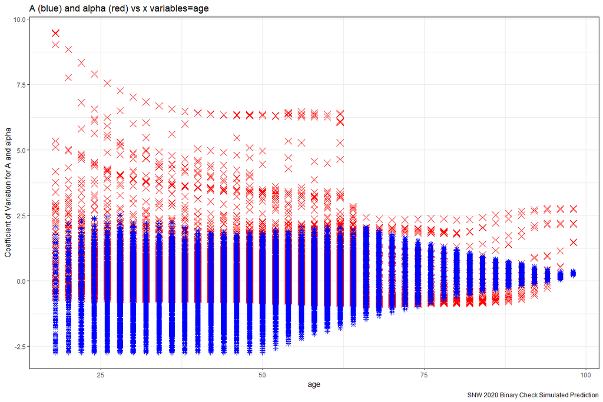

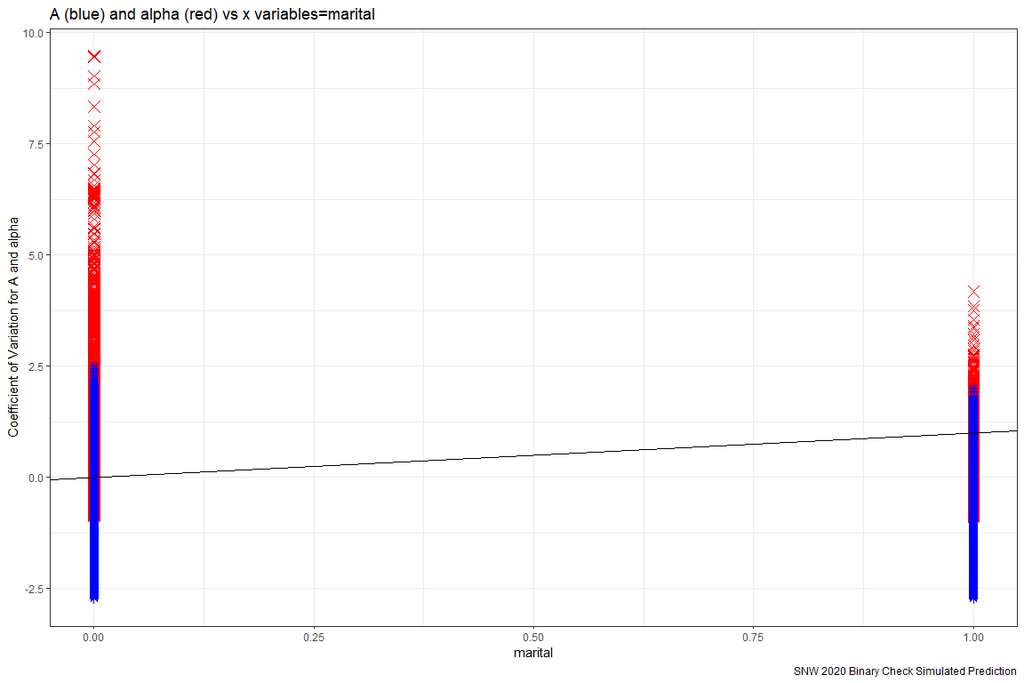

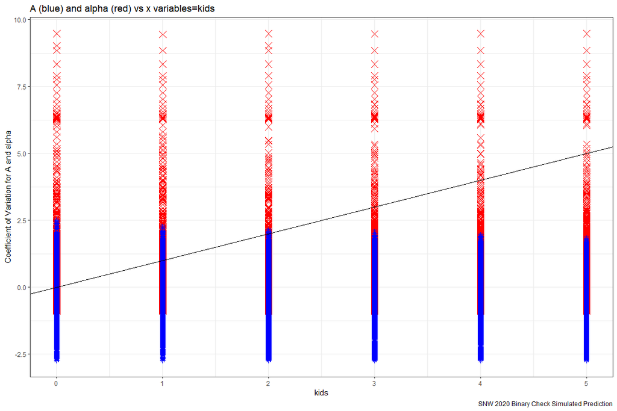

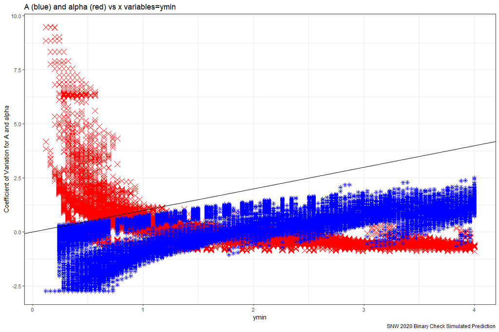

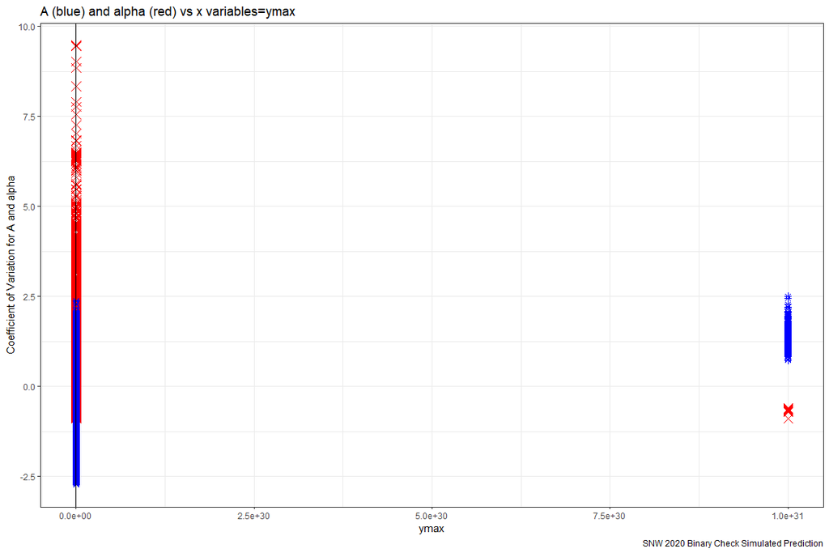

```r
ls_st_xs <- ar_svr_groups
# ls_st_xs <- ar_svr_groups <- c('age', 'marital')
lapply(ls_st_xs,
       ggplot.A.alpha.x,
       df = df_il_U_join_states)
```